# Hold’em Strategies

Alex

2023-02-11

# Overview

In Texas Hold’em, two cards, known as hole cards, are dealt face down to each player, and then five community cards are dealt face up in three stages. Each player seeks the best five card poker hand from any combination of the seven cards; the five community cards and their two hole cards. This document is a game simulation on Texas Hold’em in a heads up(1v1) scenario. The goal of this simulation to test the better strategy between only playing if player has a pair or two cards of the same suit and when player has two cards that is less than 4 cards apart.

# Setup

The simulation setup creates a deck of 52 cards for each simulated hand. 5 community cards, 2player cards and 2 enemy cards are dealt from each deck for every hand. This cards are wrangled into a data frame that includes the card value, player and hand. Showing the first 2 hands.

```
##    hand    player     suit number value
## 1     1        Me   Spades      7    12
## 2     1        Me   Spades      9    12
## 3     1     Enemy    Clubs      5     5
## 4     1     Enemy Diamonds      6     2
## 5     1 Community   Hearts      8     9
## 6     1 Community    Clubs      4     5
## 7     1 Community    Clubs      6     5
## 8     1 Community   Hearts      4     8
## 9     1 Community   Spades      6    12
## 10    2        Me Diamonds      4    14
## 11    2        Me Diamonds      3    14
## 12    2     Enemy   Hearts      9     9
## 13    2     Enemy   Hearts      8     9
## 14    2 Community Diamonds   JACK     3
## 15    2 Community   Hearts    ACE     7
## 16    2 Community    Clubs   JACK     6
## 17    2 Community    Clubs      6     5
## 18    2 Community Diamonds    ACE    14
```

# Checking the winner

Here are the ranking of combinations to determine the winner. (From Strongest to weakest)

1. Royal flush A, K, Q, J, 10, all the same suit.
2. Straight flush Five cards in a sequence, all in the same suit.
3. Four of a kind All four cards of the same number.
4. Full house Three of a kind with a pair.
5. Flush Any five cards of the same suit, but not in a sequence.
6. Straight Five cards in a sequence, but not of the same suit.
7. Three of a kind Three cards of the same number.
8. Two pair Two different pairs.
9. Pair Two cards of the same number.
10. High Card When you haven’t made any of the hands above, the highest card wins.

Creating a function to determine the winner.

```
## winners
## Enemy    Me
##  5135  4865
```

# Strategy1

Only go when two cards are the same suit or same number

```
## [1] "31%"
```

Winning percentage with strategy1 is 31% out of total wins.

# Strategy2

Only go when the difference between the cards is less than or equals to 4.

```
## [1] "48%"
```

Winning percentage with strategy2 is 48% out of total wins.

# Conclusion

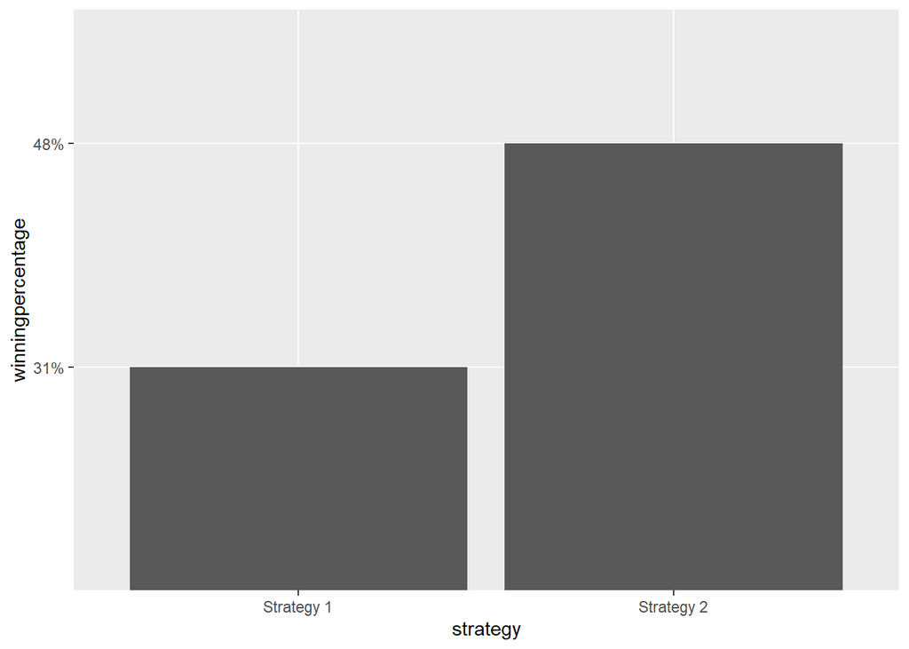

The percentage of winning for Strategy 2 is higher with 48% chance of all the winning hands.